# Descriptive Analysis

Anonymous

13 8 2020

This doc gives some exploratory insight into the DataSet

A total of *n=*174 completed the questionnaire at least to the point of the bonus questions.

# Demographics:

Almost all participants stated, that they did experience a videogame as art:

|  | Freq | % Valid |
| --- | --- | --- |
| Yes | 168 | 96.551724 |
| No | 6 | 3.448276 |

Age and Gender were distributed as follows:

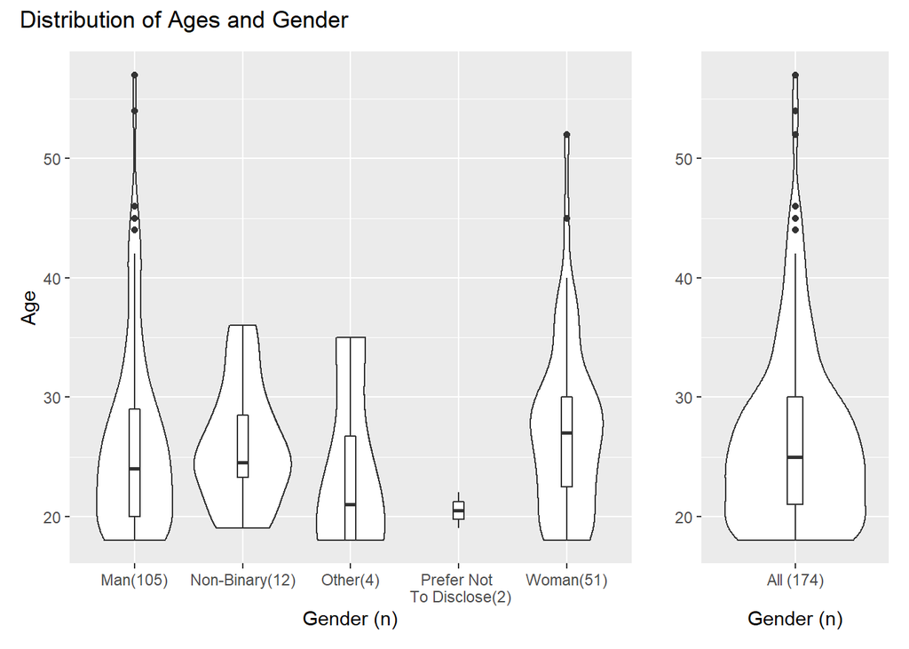

# The Experience of Videogames as Art.

Of the 174 participants, 168 indicated they experienced games as art.

| Changed Perspective on Game: (out of 150) | Changed Perspective on Self: (out of 150) | Changed Perspective on Medium: (out of 150) | Experience was the Developers Intention (out of 150) |
| --- | --- | --- | --- |
| 120 | 92 | 61 | 131 |

It should be noted, that many participants who indicated that the experience did not change their opinion on the medium stated that they already saw games as a form of art (e.g., ID 8, 12, 67, 87, 116). This may indicate, that at least among video game players, the discussion that games are art is not really held anymore.

We further asked participants to state up to five of their favorite games. We compared these to the game they described as an artful experience.

[output not shown]

[output not shown]

[output not shown]

[output not shown]

[output not shown]

[output not shown]

[output not shown]

[output not shown]

[output not shown]

[output not shown]

[output not shown]

[output not shown]

[output not shown]

[output not shown]

[output not shown]

[output not shown]

[output not shown]

[output not shown]

[output not shown]

[output not shown]

[output not shown]

[output not shown]

[output not shown]

[output not shown]

[output not shown]

[output not shown]

[output not shown]

[output not shown]

[output not shown]

[output not shown]

[output not shown]

[output not shown]

[output not shown]

[output not shown]

[output not shown]

[output not shown]

[output not shown]

[output not shown]

[output not shown]

[output not shown]

[output not shown]

[output not shown]

[output not shown]

[output not shown]

[output not shown]

[output not shown]

[output not shown]

[output not shown]

[output not shown]

[output not shown]

[output not shown]

[output not shown]

[output not shown]

[output not shown]

[output not shown]

[output not shown]

[output not shown]

[output not shown]

[output not shown]

[output not shown]

[output not shown]

[output not shown]

[output not shown]

[output not shown]

[output not shown]

[output not shown]

[output not shown]

Of the 168 participants indicating an artful videogame experience, 89 (52.98%) counted the game as one of their favourites. It has to be noted, that this observation might, in part be due to the availability of said title, as the recollection task was done before the participants named up to five of their favourite games.

Another confounding factor might be that many participants recounted a rather recent experience:

|  | Freq | % Valid |
| --- | --- | --- |
| <2 months ago | 54 | 32.142857 |
| 2-11 months ago | 39 | 23.214286 |
| 1-2 years ago | 33 | 19.642857 |
| 2-10 years ago | 33 | 19.642857 |
| >10 years ago | 9 | 5.357143 |
|  | 0 | NA |
| Total | 168 | 100.000000 |

Several games where mentioned quite a lot by the participants, both as a game to elicit an artful experience and being on of the participants favourite games.

| Elicited and Artful Experience | Mentions |
| --- | --- |
| THE LEGEND OF ZELDA: BREATH OF THE WILD | 8 |
| JOURNEY | 7 |
| NIER: AUTOMATA | 6 |
| RED DEAD REDEMPTION 2 | 6 |
| FIREWATCH | 5 |
| HOLLOW KNIGHT | 5 |
| DISCO ELYSIUM | 3 |
| LIFE IS STRANGE | 3 |
| THE LAST OF US PART 2 | 3 |
| THE WITCHER 3: WILD HUNT | 3 |

| Favourite Game | Mentions |
| --- | --- |
| THE ELDER SCROLLS 5: SKYRIM | 25 |
| THE LEGEND OF ZELDA: BREATH OF THE WILD | 22 |
| MINECRAFT | 18 |
| THE WITCHER 3: WILD HUNT | 14 |
| STARDEW VALLEY | 9 |
| THE LAST OF US | 8 |
| WORLD OF WARCRAFT | 8 |
| ANIMAL CROSSING | 7 |
| BORDERLANDS 2 | 7 |
| HOLLOW KNIGHT | 7 |

It has to be noted, that while Skyrim is by far the game mentioned most often as a favourite, only 2 people (ID456, 666) mentioned it as their artful experience.

For 72.02% of participants, the experience happened during their first exposure to the game.

When asked where in the game the experience happened, many participants indicated, that the experience happened during the general gameplay, not at any specific moment. People who indicated “Other”, often times pointed out, that the whole game was deemed as the described experience (e.g., ID 11, 13, 20, 22, 27). Further, it could be that when mentioning their favourite game, not all people specified that they meant The Last of Us Part 2, leading to a higher mention of it as a favourite game while Part 2 was mentioned more often as an artful experience. (Further, two people indicated both The Last of Us 1 and 2 as their favourite games)

[output not shown]

# Descriptives for the AESTHEMOS

## General Descriptive AESTHEMOS Data

The following tables feature the Mean and SD of each Item and Subscale of the AESTHEMOS

Tables for the AESTHEMOS Items:

### 1: Feeling Of Beauty

| Mean_LikedIt | SD_LikedIt | Mean_Beautiful | SD_Beautiful | Mean_FeelingOfBeauty | PooledSD_FeelingOfBeauty |
| --- | --- | --- | --- | --- | --- |
| 4.690476 | 0.6088409 | 4.541667 | 0.874483 | 4.616071 | 0.7534613 |

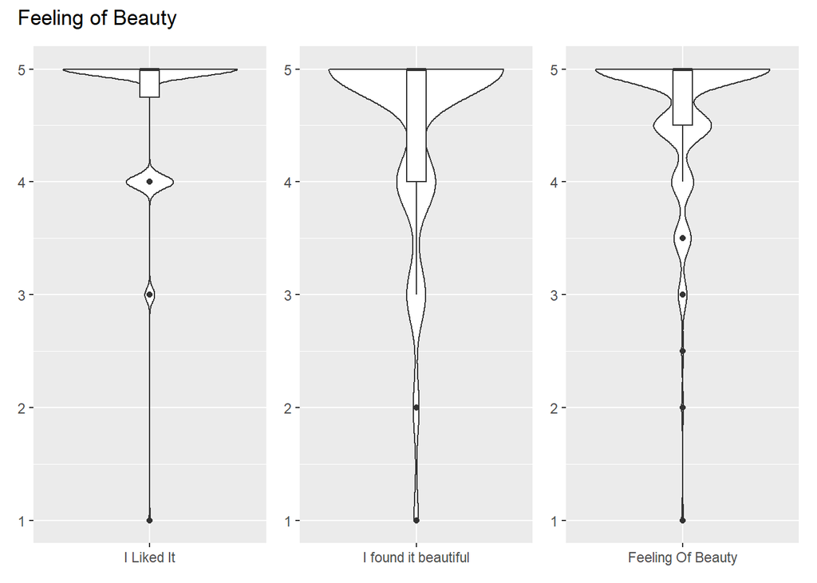

### 2: Fascination

| Mean_Impressed | SD_Impressed | Mean_Fascinated | SD_Fascinated | Mean_Fascination | PooledSD_Fascination |
| --- | --- | --- | --- | --- | --- |
| 4.321429 | 0.9370704 | 4.226191 | 0.9584317 | 4.273809 | 0.9478112 |

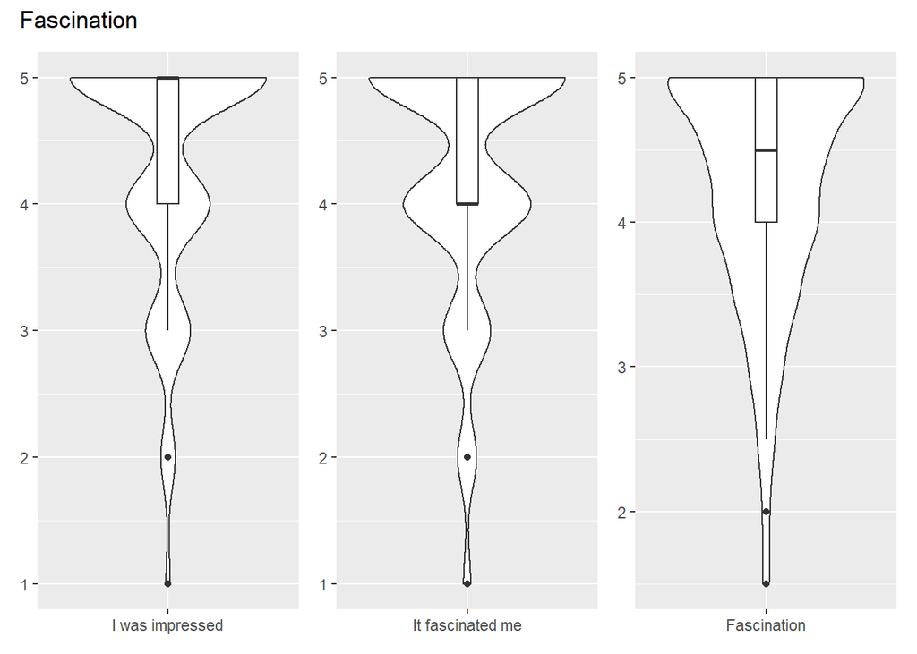

### 3: Being Moved

| Mean_DeeplyMoved | SD_DeeplyMoved | Mean_Touched | SD_Touched | Mean_BeingMoved | PooledSD_BeingMoved |
| --- | --- | --- | --- | --- | --- |
| 3.827381 | 1.29484 | 3.964286 | 1.232751 | 3.895833 | 1.264177 |

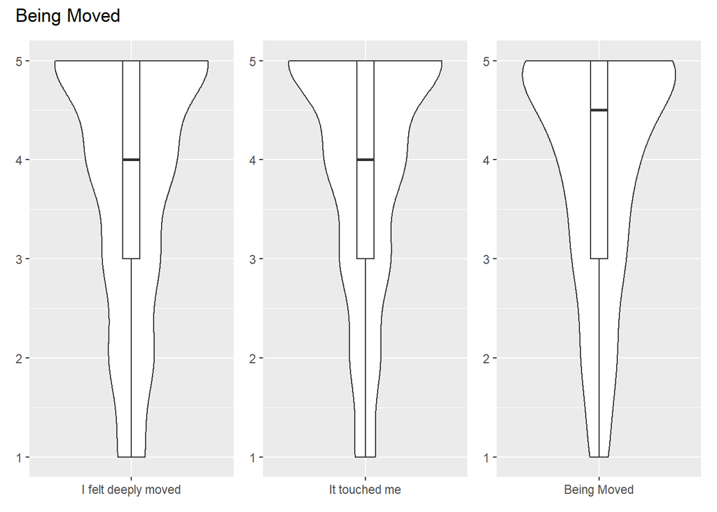

### 4: Awe

| Mean_Sublime | SD_Sublime | Mean_FeltAwe | SD_FeltAwe | Mean_Awe | PooledSD_Awe |
| --- | --- | --- | --- | --- | --- |
| 3.964286 | 1.110067 | 3.654762 | 1.326777 | 3.809524 | 1.223231 |

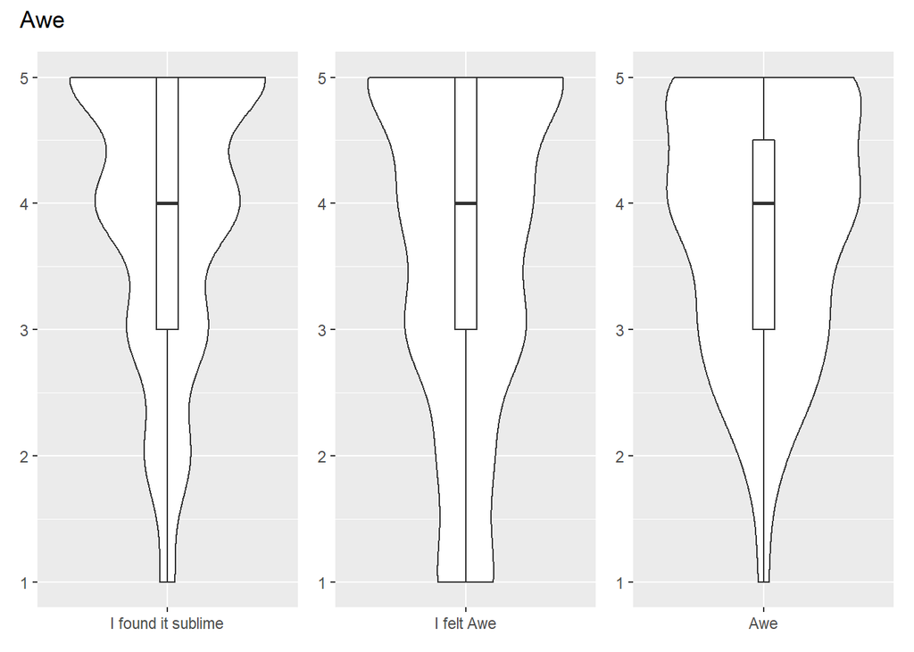

### 5: Enchantment

| Mean_SomethingWonderful | SD_SomethingWonderful | Mean_Enchanted | SD_Enchanted | Mean_Entchantment | PooledSD_Entchantment |
| --- | --- | --- | --- | --- | --- |
| 4.005952 | 1.165867 | 4.113095 | 1.134255 | 4.059524 | 1.15017 |

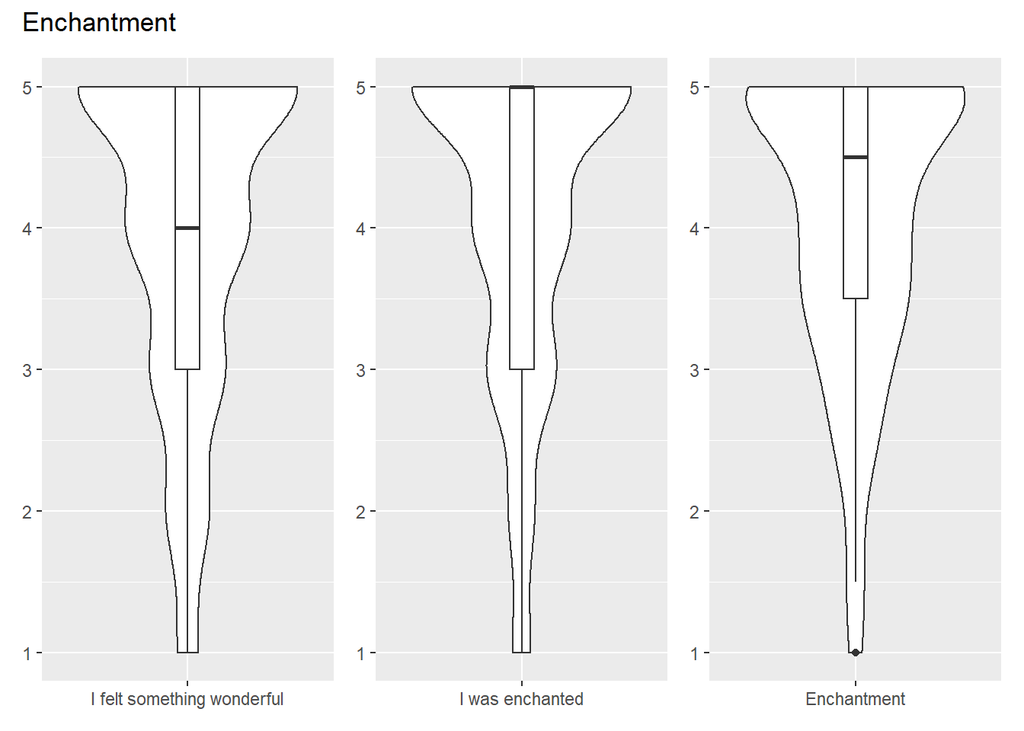

### 6: Nostalgia

| Mean_Nostalgic | SD_Nostalgic | Mean_Sentimental | SD_Sentimental | Mean_Nostalgia | PooledSD_Nostalgia |
| --- | --- | --- | --- | --- | --- |
| 3.672619 | 1.360244 | 2.964286 | 1.519899 | 3.318452 | 1.442282 |

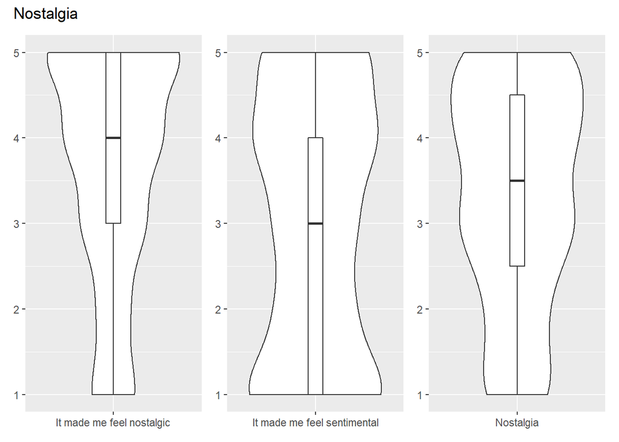

### 7: Joy

| Mean_Delight | SD_Delight | Mean_Happy | SD_Happy | Mean_Joy | PooledSD_Joy |
| --- | --- | --- | --- | --- | --- |
| 3.797619 | 1.155873 | 3.779762 | 1.254575 | 3.78869 | 1.206234 |

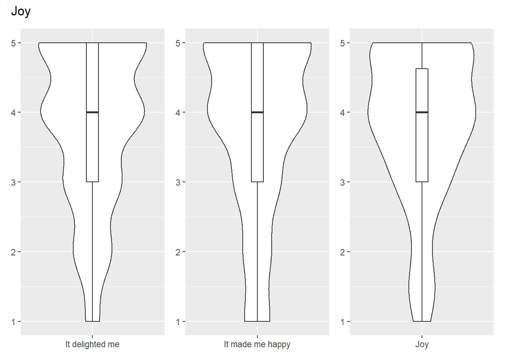

### 8: Humor

| Mean_Amused | SD_Amused | Mean_Funny | SD_Funny | Mean_Humor | PooledSD_Humor |
| --- | --- | --- | --- | --- | --- |
| 3.107143 | 1.375734 | 2.267857 | 1.310817 | 2.6875 | 1.343668 |

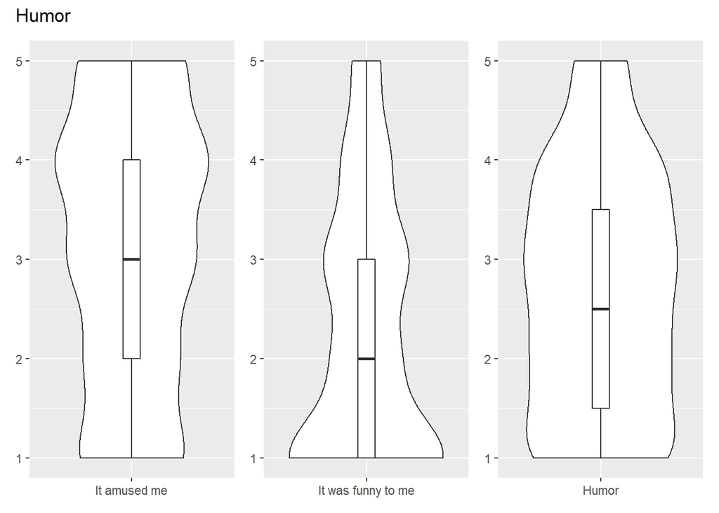

### 9: Vitality

| Mean_Spurred | SD_Spurred | Mean_Invigorated | SD_Invigorated | Mean_Vitality | PooledSD_Vitality |
| --- | --- | --- | --- | --- | --- |
| 3.113095 | 1.351095 | 3.071429 | 1.283574 | 3.092262 | 1.317767 |

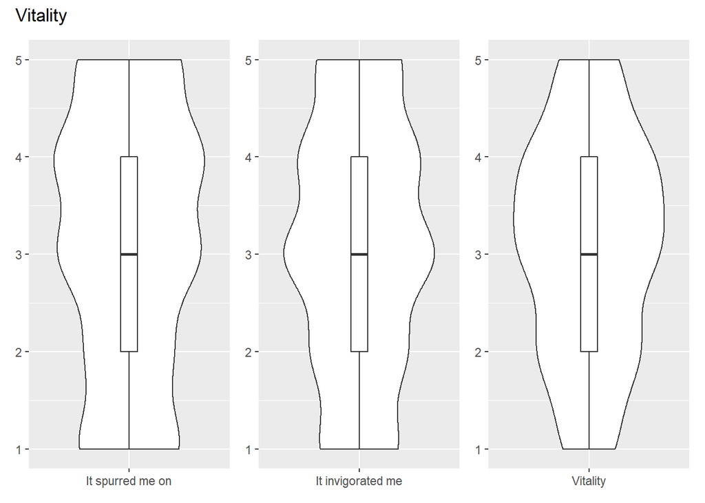

### 10: Energy

| Mean_Motivated | SD_Motivated | Mean_Energized | SD_Energized | Mean_Energy | PooledSD_Energy |
| --- | --- | --- | --- | --- | --- |
| 3.095238 | 1.239268 | 2.958333 | 1.398691 | 3.026786 | 1.321386 |

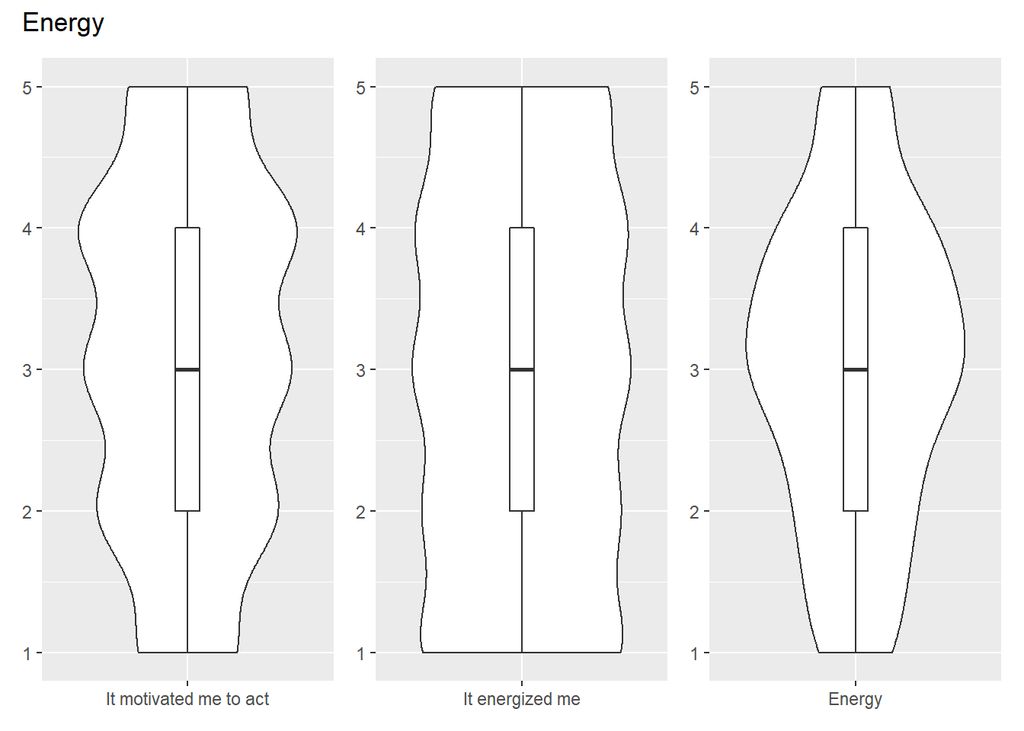

### 11: Relaxation

[output not shown]

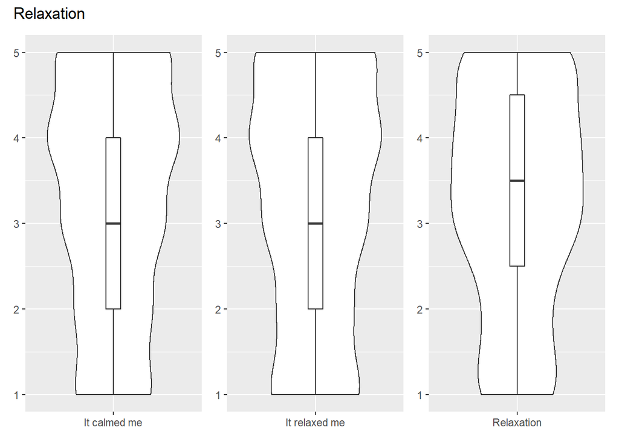

### 12: Surprise

| Mean_Baffled | SD_Baffled | Mean_SurprisedMe | SD_SurprisedMe | Mean_Surprise | PooledSD_Surprise |
| --- | --- | --- | --- | --- | --- |
| 2.470238 | 1.357726 | 3.761905 | 1.149007 | 3.116071 | 1.257704 |

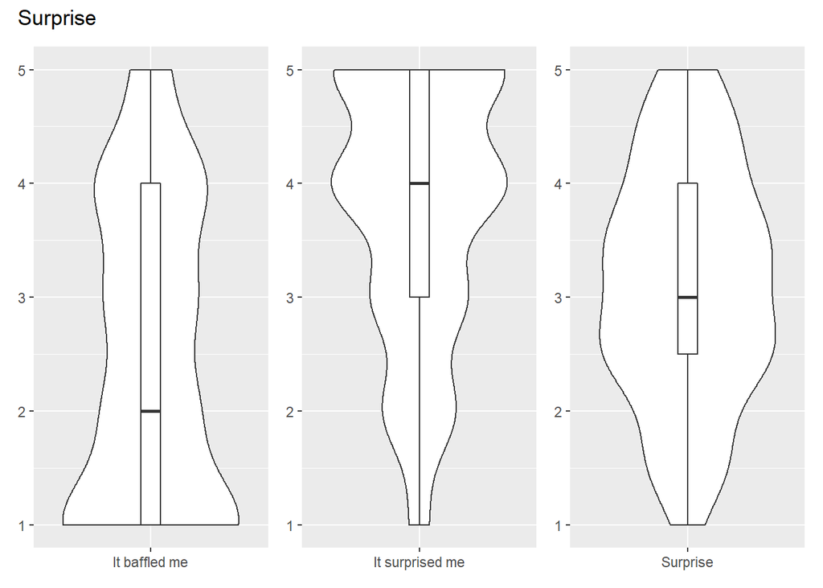

### 13: Interest

| Mean_Curious | SD_Curious | Mean_SparkedIntererst | SD_SparkedIntererst | Mean_Interest | PooledSD_Interest |
| --- | --- | --- | --- | --- | --- |
| 4.273809 | 0.9521635 | 3.779762 | 1.235336 | 4.026786 | 1.102876 |

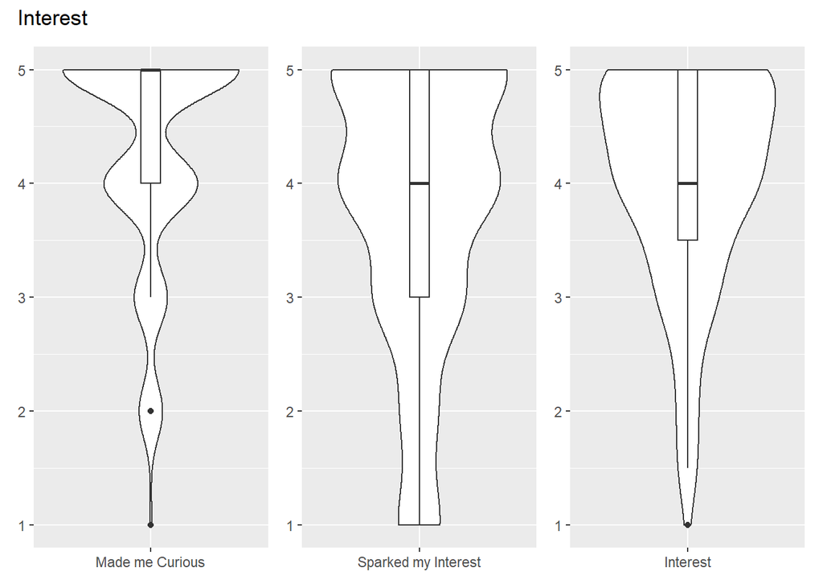

### 14: Intellectual Challenge

| Mean_Challenged | SD_Challenged | Mean_Engaged | SD_Engaged | Mean_IntellectualChallenge | PooledSD_IntellectualChallenge |
| --- | --- | --- | --- | --- | --- |
| 3.267857 | 1.306241 | 4.184524 | 1.000837 | 3.72619 | 1.163602 |

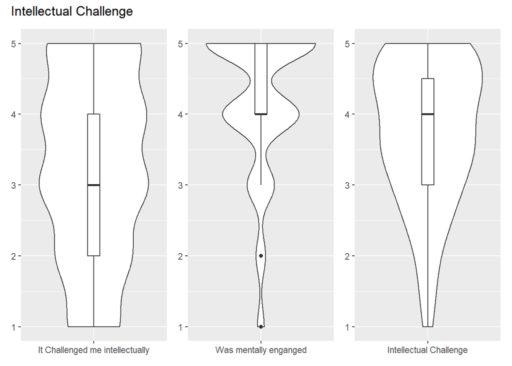

### 15: Insight

| Mean_SuddenInsight | SD_SuddenInsight | Mean_DeeperMeaning | SD_DeeperMeaning | Mean_Insight | PooledSD_Insight |
| --- | --- | --- | --- | --- | --- |
| 4.011905 | 1.257257 | 3.303571 | 1.343687 | 3.657738 | 1.30119 |

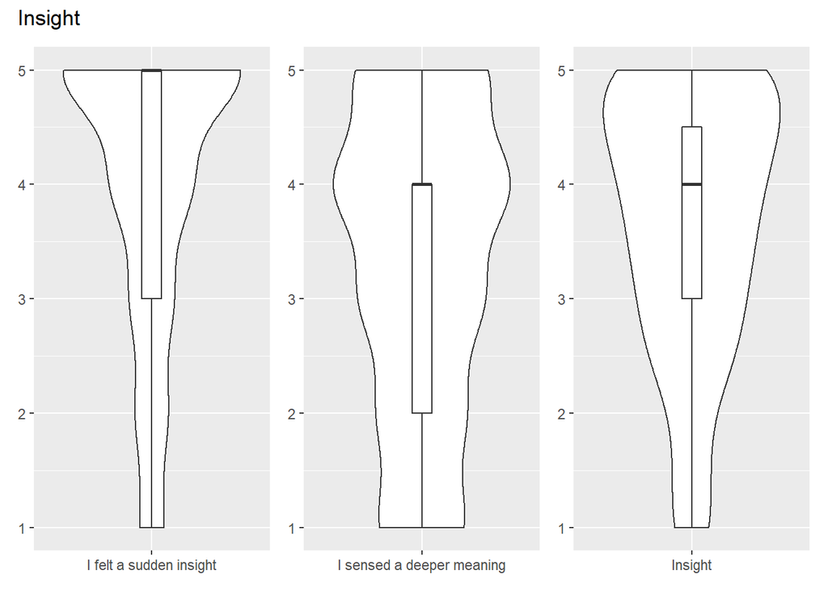

### 16: Feeling of Ugliness

| Mean_Distasteful | SD_Distasteful | Mean_Ugly | SD_Ugly | Mean_FeelingOfUgliness | PooledSD_FeelingOfUgliness |
| --- | --- | --- | --- | --- | --- |
| 1.47619 | 0.9785262 | 1.178571 | 0.5925832 | 1.327381 | 0.8089093 |

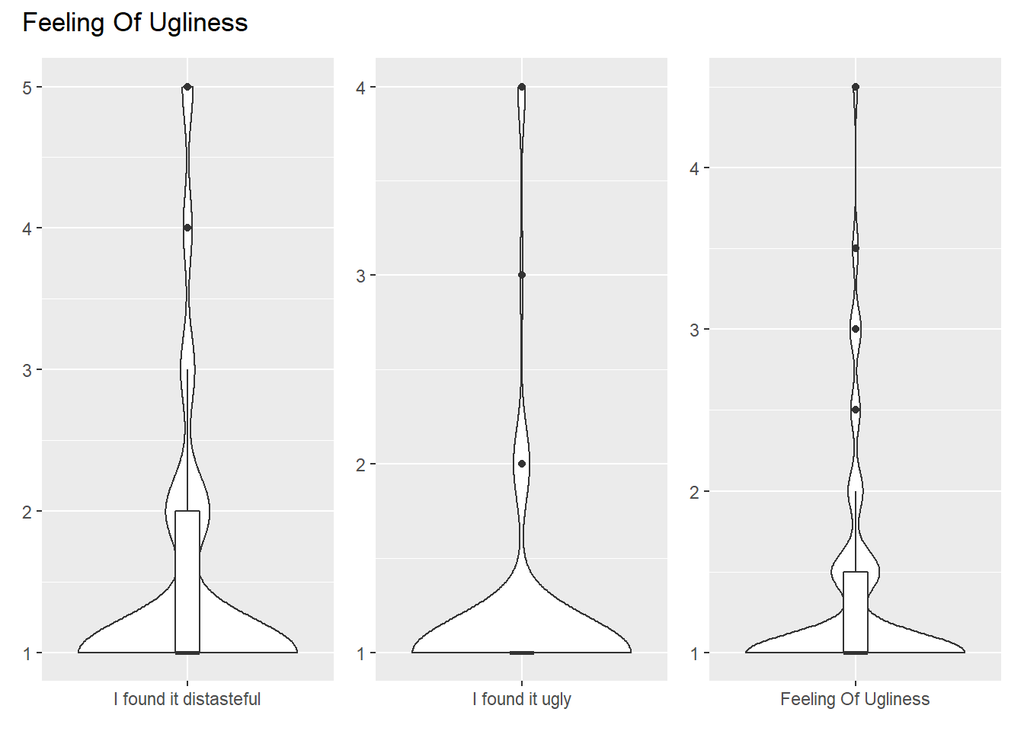

### 16: Boredom

| Mean_Indifferent | SD_Indifferent | Mean_Bored | SD_Bored | Mean_Boredom | PooledSD_Boredom |
| --- | --- | --- | --- | --- | --- |
| 1.214286 | 0.5377137 | 1.39881 | 0.8899968 | 1.306548 | 0.7352654 |

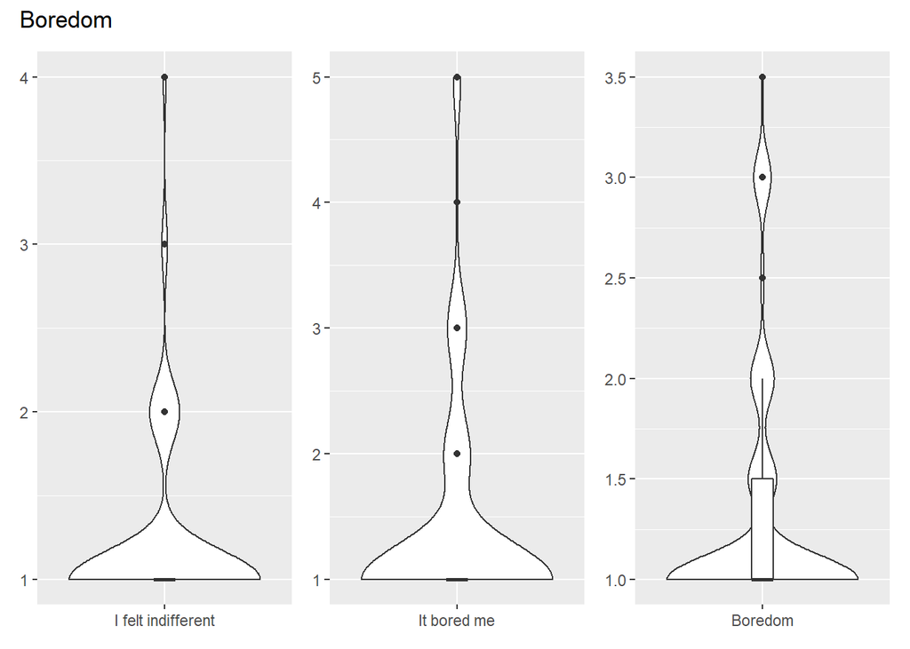

### 18: Confusion

| Mean_Confused | SD_Confused | Mean_Unsettling | SD_Unsettling | Mean_Confusion | PooledSD_Confusion |
| --- | --- | --- | --- | --- | --- |
| 2.172619 | 1.183707 | 2.142857 | 1.314524 | 2.157738 | 1.250827 |

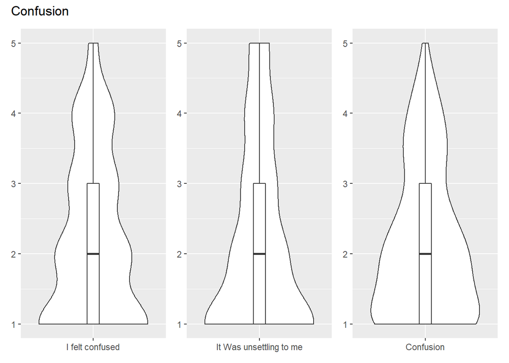

### 19: Anger

| Mean_Aggressive | SD_Aggressive | Mean_Angry | SD_Angry | Mean_Anger | PooledSD_Anger |
| --- | --- | --- | --- | --- | --- |
| 1.678571 | 1.123091 | 1.422619 | 0.885661 | 1.550595 | 1.011368 |

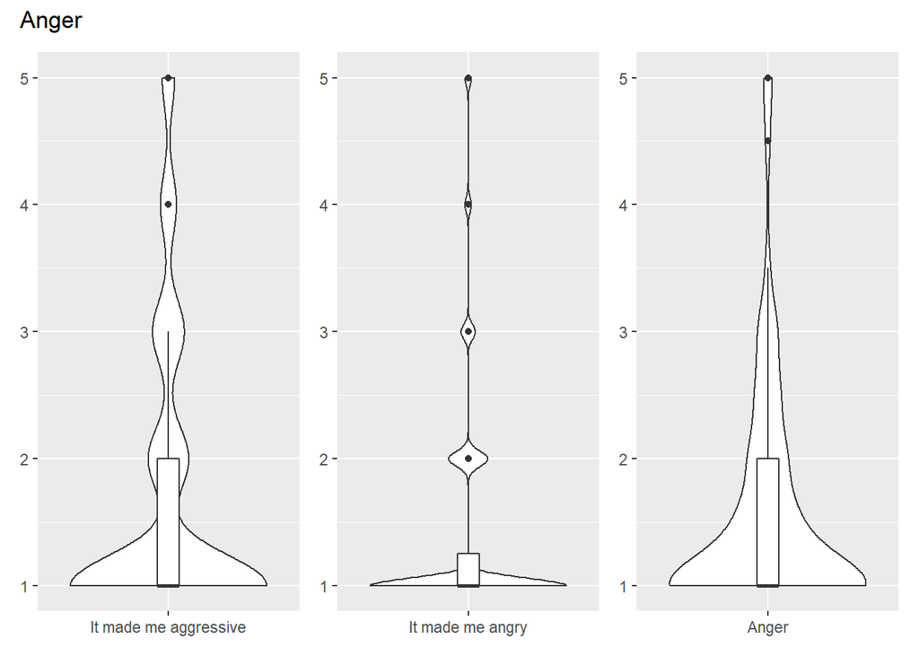

### 20: Uneasiness

| Mean_Worried | SD_Worried | Mean_Oppressive | SD_Oppressive | Mean_Uneasiness | PooledSD_Uneasiness |
| --- | --- | --- | --- | --- | --- |
| 1.767857 | 1.228276 | 1.928571 | 1.250492 | 1.848214 | 1.239434 |

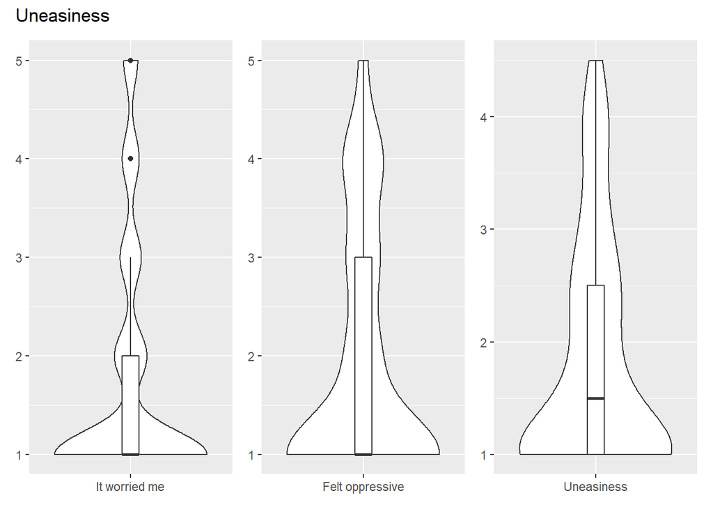

### 21: Sadness

| Mean_Sad | SD_Sad | Mean_Melancholic | SD_Melancholic | Mean_Sadness | PooledSD_Sadness |
| --- | --- | --- | --- | --- | --- |
| 3.095238 | 1.448675 | 2.958333 | 1.477796 | 3.026786 | 1.463308 |

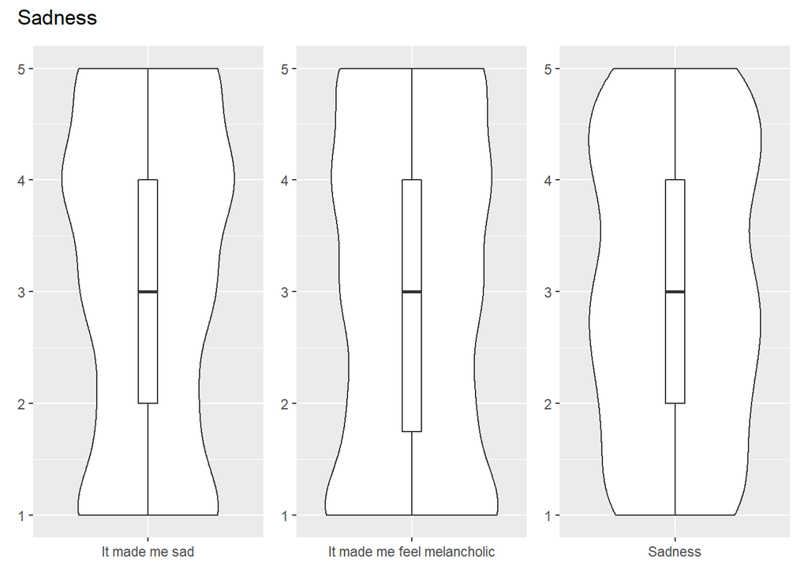

## Scale Reliablity

We computed Cronbach’s and compared it to the reliability reported by Schindler et al. (2017)

| Subscale | MeasuredCronbach | AESTHEMOSCronbach | Difference |
| --- | --- | --- | --- |
| Awe | 0.45 | 0.55 | -0.10 |
| Boredom | 0.46 | 0.75 | -0.29 |
| Surprise | 0.52 | 0.75 | -0.23 |
| FeelingOfUgliness | 0.54 | 0.71 | -0.17 |
| Energy | 0.56 | 0.66 | -0.10 |
| Uneasiness | 0.58 | 0.75 | -0.17 |
| Fascination | 0.60 | 0.77 | -0.17 |
| Interest | 0.62 | 0.69 | -0.07 |
| Feeling of beauty | 0.65 | 0.73 | -0.08 |
| Vitality | 0.65 | 0.80 | -0.15 |
| Confusion | 0.65 | 0.75 | -0.10 |
| Intellectual challenge | 0.68 | 0.78 | -0.10 |
| Insight | 0.72 | 0.64 | 0.08 |
| Anger | 0.73 | 0.75 | -0.02 |
| Sadness | 0.73 | 0.73 | 0.00 |
| Enchantment | 0.74 | 0.79 | -0.05 |
| Nostalgia | 0.74 | 0.73 | 0.01 |
| Humor | 0.79 | 0.85 | -0.06 |
| Joy | 0.80 | 0.84 | -0.04 |
| Relaxation | 0.84 | 0.60 | 0.24 |
| Being moved | 0.87 | 0.77 | 0.10 |

# Exploring Expertise

Expertise was measured via several measures: - For how long have they been playing (in Years) - how many hours do they play per week - Self reported Experience (0-100) - Self reported broadness of taste (0-100) - A selection of Genres people prefer

| TimeInYears_mean | TimeInYears_SD | TimePerWeek_mean | TimePerWeek_SD | SelfReportedExperience_mean | SelfReportedExperience_SD | SelfReportedBroadnessOfTaste_mean | SelfReportedBroadnessOfTaste | EnjoyedGenres_mean | EnjoyedGenres_SD |
| --- | --- | --- | --- | --- | --- | --- | --- | --- | --- |
| 18.10345 | 7.997159 | 14.7069 | 13.01001 | 78.71598 | 22.12039 | 63.78363 | 28.39646 | 6.574713 | 2.966605 |

Expertise was measured directly via two continuous self report measures:

- Experience
- Broadness of Taste

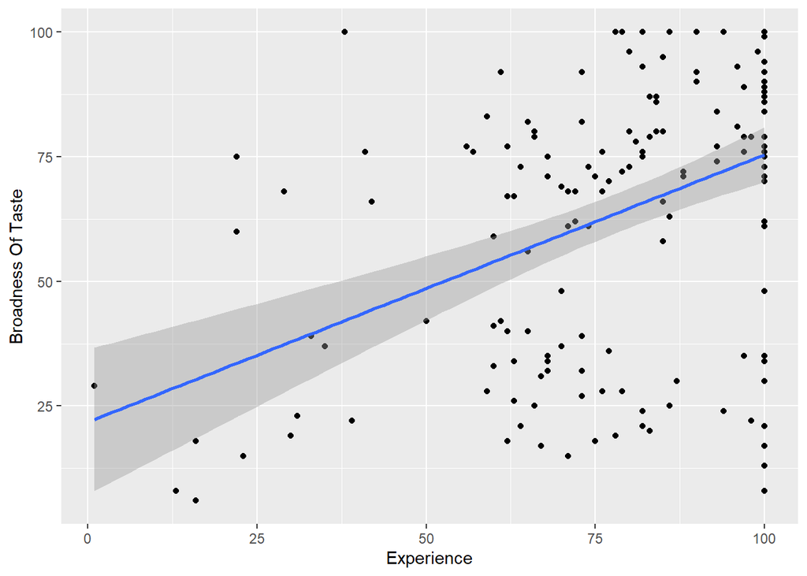

These two measures had a medium correlation (*r =* 0.4192103). Ths indicates, that a higher experience might come with a broadened taste.

Additionally participants indicated the time since they started playing

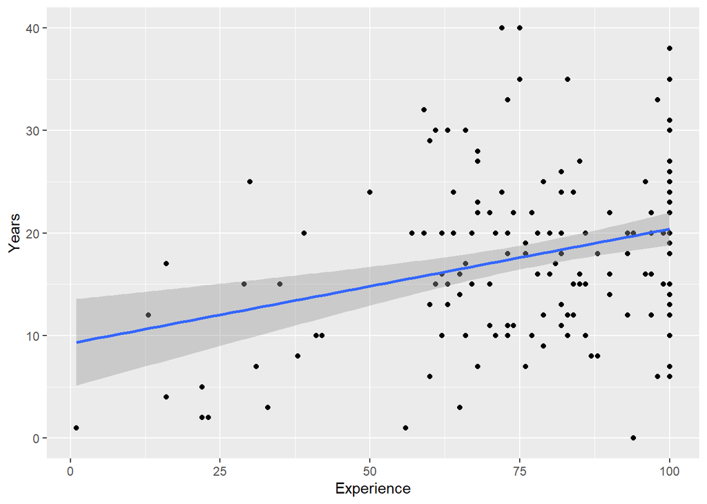

The measures had a medium correlation (*r =* 0.3105851)

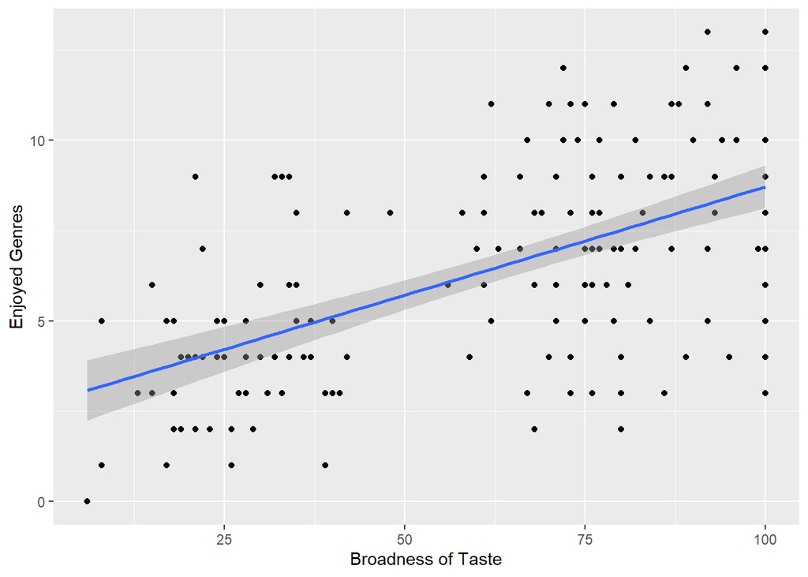

As expected, the self report of broadness of taste correlates highly with the enjoyed genres (*r =* 0.5749135).

Further, participants indicated if they worked in the gaming industry or worked as Artists:

Of the 174 participants, 25 worked on or with video games and 49 worked on or with art. 16 participants described themselves as working or having worked in both fields. Interestingly, one participants (ID620) works in both fields while stating to not have had an artistic experience. However, this might not be due to an absence of an artistic experience but due to the participants rejection of the “[…] Art, as it’s commonly understood and applied in general discourse […]”.

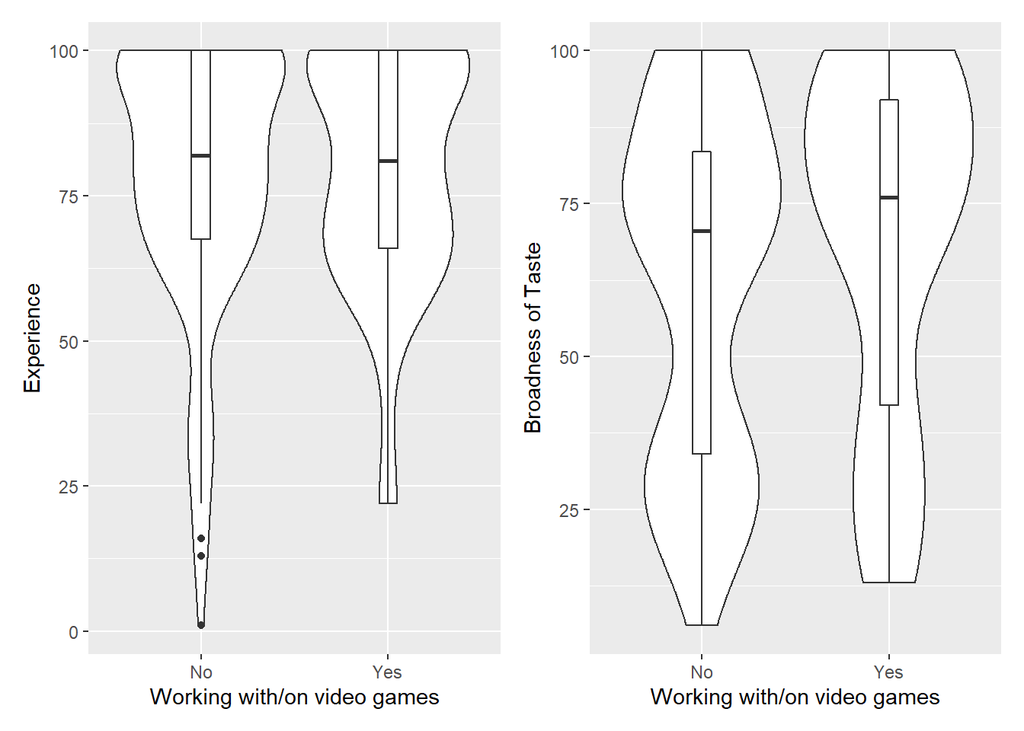

While people working with videogames barely differentiate themselves from the other participants, they report a slightly broader taste. However, given the vast different in sample size, this should be taken with a grain of salt.

# The Absence of Videogames as Art.

Few people indicated, that they never had any experience with video games that they would classify as art 6 (3.45%). Of these 4 (66.67%) indicated they had experience with other forms of art. As written before, ID620 indicated, that they did not believe in the term art and therefore did not agree with any of the questions.

Besides ID620 only one other person noted, that videogames cannot be experienced as art as, while the parts my be art, the game itself is only a vessel and therefore not itself art.